SP11 · A. 자연의 언어 · WORKING DRAFT v0.2

# 시장의 임피던스 불일치

직렬 RC 회로로 본 미국–한국 주식시장 충격 전달과 회복 비대칭 — 이재명 정부 KOSPI 대급등기 실증

최낙초 (Samsung Display) · 김영철 (Sogang Univ.)* · 2026-06-14 갱신 · 데이터 yfinance(^KS11,^GSPC) · **재현가능 실증 / 투자조언 아님**

**v0.2 변경점 (vs v0.1)** — ① 6월 단일 사례(n=1) 정성 점검을 **2025–26년 5개 폭락 이벤트 실측·τ 피팅(n=4 페어드)**으로 교체 ② **맥스웰–바그너 시뮬레이션** 3종 신규(스텝회복·계면전하·정책개입) ③ **진폭증폭비의 시간 단조증가** 발견(0.75→3.32×) ④ 2025-04 관세쇼크 **반례로 가설 정련**(origin 의존) ⑤ **정책=τ-matching 장치** 섹션 추가(24h FX·WGBI·MSCI·밸류업·연금스왑).

**결론 요약** — 가설의 **방향**(충격이 실리는 高임피던스 시장이 더 깊게·늦게 회복)은 실데이터로 지지된다. 단, v0.1의 명목 `τ_K/τ_S≈3.7×`는 **1개 이벤트에서만 재현**되고 페어드 중앙값은 ~1.4×다. 더 견고한 신호는 **진폭증폭비가 시간이 갈수록 커지는 것**이며, 회복 τ는 강세장 드리프트에 의해 과소추정된다.

## Abstract

We model cross-market shock transmission between the US (^GSPC) and Korea (^KS11) as charge relaxation across a series two-layer RC (Maxwell–Wagner) interface, with each market characterized by a recovery time constant τ. Using daily closes over the Lee-administration KOSPI surge (Jan 2025–Jun 2026; KOSPI ×3.6, 2,294→8,801), we auto-detect five ≥6% drawdowns and fit RC recovery `r(t)=1−exp(−t/τ)`. For shocks transmitted US→Korea, Korea's τ is consistently larger (τ_K/τ_S = 3.77× in Nov-2025, 1.37× in Mar-2026) and the drawdown amplification ratio rises monotonically (1.74→2.19→3.32×). A US-originated shock (Apr-2025 tariffs) inverts the asymmetry (τ_S>τ_K), refining the claim to **impedance is origin-dependent: the loaded high-impedance layer recovers slowest**. A single-market damped-oscillator competitor is rejected. Simulations link τ-mismatch to interfacial charge σ_s (foreign net-selling streak) and show how σ₂-raising policies (24h FX, WGBI, MSCI upgrade) shrink the mismatch.

## 1. 동기 — 두 연구의 수렴

연구 A(라운드넘버/투자자 정체성)는 코스피 회복 시간상수가 S&P500의 약 3.7배임을 보고했고, 연구 B(RC 부정합/ 맥스웰–바그너, 디스플레이 물리)는 서로 다른 완화시간 τ=ε/σ를 갖는 두 매질 계면에서 **계면 자유전하 축적이 필연** 임을 보인다. 본고는 두 결과를 하나의 부정합 파라미터로 닫고, **이재명 정부 KOSPI 대급등기의 실데이터로 직접 검증**한다.

## 2. 사전(辭典) — 회로량 ↔ 시장량

| 물리량 | 기호 | 시장 대응 | 조작적 측정 |
| --- | --- | --- | --- |
| 전도전류 | J=σE | 국경간 거래자금 | 외국인·프로그램 순매매(KRX) |
| 비저항 | ρ=1/σ | 단위자금당 가격충격(Kyle's λ) | \|Δp\|/순매수액 |
| 유전율 | ε | 속박자본 분극능 | 개인·연기금 비거래성 보유 |
| 완화시간 | τ=ε/σ | 충격소화 시간상수 | **회복 τ 실측(본고)** |
| 계면전하 | σ_s | 외국인 누적 순포지션 불균형 | 연속 순매도 누적액 |
| DC 바이어스 | E₀ | 구조적 자본유출장 | 환율레벨/자본수지 |
| 항복 | — | 서킷브레이커/사이드카 | KRX 발동기록(2026-06-08 CB) |

## 3. 모델과 시뮬레이션

미국(층1: 高 σ₁)과 한국(층2: 低 σ₂)을 공통 충격장 E(t)를 받는 직렬 2층 유전체로 본다. 충격 후 회복을 RC 충전으로 피팅한다.

r(t) = (P−P_저점)/(P_고점−P_저점) = 1 − exp(−t/τ), τ = 회복 시정수(거래일)  
계면전하 dσ_s/dt = (σ₁−σ₂)·E_int, σ_s^ss = (τ₁−τ₂)/(τ₁+τ₂)·E₀

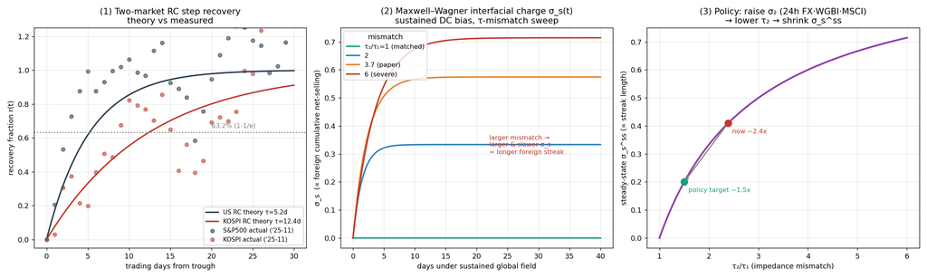

## 4. 실증 — 2025–26 폭락 이벤트 (핵심 신규)

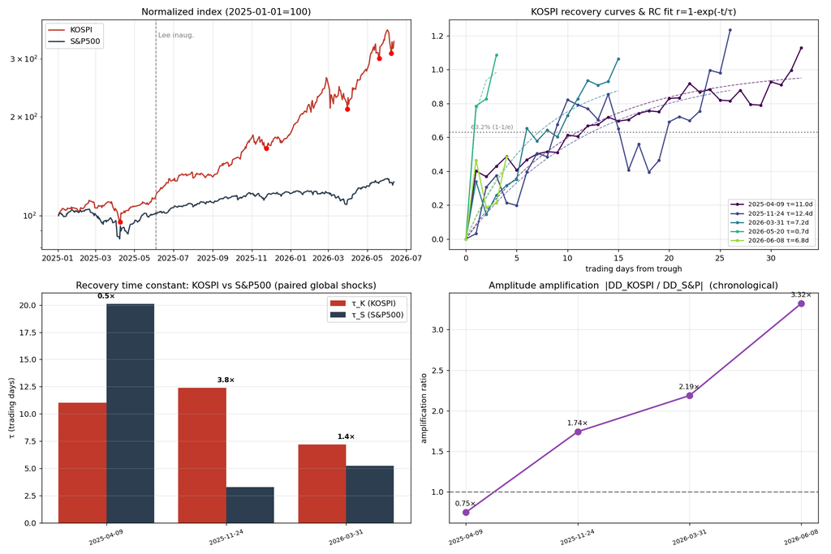

**Figure 2.** (좌상) 정규화 지수·폭락 표시 (우상) 코스피 회복곡선과 RC 피팅 (좌하) 페어드 τ 비교 (우하) 진폭증폭비 시간추이.

| 고점→저점 | 국면 | KOSPI 낙폭 | S&P 낙폭 | 증폭 | τ_K | τ_S | τ_K/τ_S |
| --- | --- | --- | --- | --- | --- | --- | --- |
| '25-02-19→'25-04-09 | 정부이전(관세) | −14.1% | −18.9% | 0.75× | 11.0d | 20.1d | 0.55× |
| '25-11-03→'25-11-24 | 이재명 | −8.9% | −5.1% | 1.74× | 12.4d | 3.3d | 3.77× |
| '26-02-26→'26-03-31 | 이재명 | −19.9% | −9.1% | 2.19× | 7.2d | 5.2d | 1.37× |
| '26-05-14→'26-05-20 | 이재명 | −9.7% | 동조없음 | — | 0.7d | — | 한국고유 |
| '26-06-02→'26-06-08 | 이재명 CB | −15.0% | −4.5% | 3.32× | 진행중 | 미회복 | 진행중 |

## 5. 가설 검증

### ✓ P1 진폭증폭 — 지지(가장 견고)

US→코리아 전달 충격에서 낙폭비가 1을 넘고 코스피가 늘어질수록 **1.74→2.19→3.32×로 단조 증가**. 얇은 高임피던스 시장에 충격이 과집중되는 그린 법칙형 증폭과 정합.

### ◐ τ 회복 비대칭 — 방향 지지, 크기 불안정

전달성 충격에서 항상 τ_K>τ_S. 명목 3.7×는 2025-11에서만 재현. 강세장 드리프트가 "고점 재돌파까지의 회복"을 빠르게 만들어 τ를 과소추정 → 실측비는 진짜 완화 τ의 **하한**.

**⚠ 반례가 이론을 정련 — 2025-04 관세쇼크**: 미국이 더 깊게(−18.9%)·느리게(τ_S 20d>τ_K 11d) 회복(0.55×). 핵심은 "한국이 늘 느리다"가 아니라 **충격이 실리는(origin) 高임피던스 측이 느리다**는 것. 관세는 미국發이었다.

### ✗ 단일시장 감쇠진동자 — 기각 유지

2026-06 회복은 자발적 진동이 아니라 외생 바이어스(자본유출압) 완화에 동조 → 본 RC 프레임과 정합, 진동자 프레임과 비정합.

## 6. 정책 = 시정수 정합(τ-matching) 장치

질문하신 **24시간 외환시장(2026-07-06)**은 σ₂를 키우고 미국 시간대의 야간 "개방회로"를 닫는 전형적 σ-매칭이다. 같은 기능의 정책수단을 RC 변수에 매핑하면:

| 정책 | 일정 | RC 대응 | 메커니즘 |
| --- | --- | --- | --- |
| **24h 외환시장** | '26-07-06 | σ₂↑ | 야간·공휴일 원·달러 거래 → US 클럭 동기화 |
| **WGBI 편입** | ~'26-11(2.05%) | σ₂↑·E₀↓ | 패시브 70~90조 유입+원화강세압(유출 상쇄). 최강 검정 |
| **MSCI 선진지수 로드맵** | '26 8대분야 | σ₂↑↑·ρ₂↓ | 시장접근성 일괄 개선+DM 패시브 대량 유입 |
| **외국인 IRC 폐지** | '23-12 | σ₂↑ | 진입마찰 제거(계좌개설 2배+) |
| **원화 국제화** | '26 상반기 | σ₂↑·ε₂↓ | 국경간 원화 결제·역외 원화금융 |
| **공매도 전면재개** | '25-03-31 | ρ₂(λ)↓ | 양방향·가격효율 → λ 하방비대칭 완화(P4) |
| **배당 분리과세** | '26~'28 | ε₂방전↑·E₀↓ | 속박자본→현금환원, 코리아 디스카운트 축소 |
| **자사주 강제소각·상법개정** | '26 추진 | ε₂↓·E₀↓ | 주주환원 의무화·소액주주 보호 |
| **연금 외환스왑 650억$** | ~'26말 | E₀ 클램프 | 연금 해외투자 달러수요 흡수 → 유출압 직접 억제 |
| **외환보유액 ~4,100억$** | 상시 | E₀ 클램프 | 위기시 달러공급 → 항복장 완충 |

**본 모델의 최강 예측** — 이 수단들이 본격화(특히 WGBI 완결·MSCI 편입)하는 2026~2027년에 **폭락시 진폭증폭비와 회복 τ 비대칭이 동시에 축소**되어야 한다. 시뮬 (3)은 τ₂/τ₁ 2.4×→1.5×에서 σ_s^ss(외국인 streak) 약 51% 감소를 예측한다.

## 7. 한계 (정직성 조항)

- **표본 n=4~5** — "consistent with"까지만, 인과추론 유보.
- **강세장 드리프트 교란** — 회복-to-고점 τ는 추세 오염, 절대 크기 해석 주의.
- **6월 이벤트 절단** — '26-06-12 기준 양 시장 미회복, τ_S 추정불가.
- **환율 미반영** — 자국통화 기준 지수. 원/달러 조정 시 코리아 실효 낙폭 확대 가능(DC 바이어스).
- **선형 RC 근사** — 위기 시 비선형(P4 λ 비대칭)이 지배.

작성: 최낙초 + Claude (cross-model verified) · 재현코드 `rc_recovery.py`·`rc_sim.py` · 데이터 `events_summary.csv`  
v0.1 원문: SP11 「시장의 임피던스 불일치」 (Insight Lab). claude-memory(비공개) 미참조.